← Back to the hackathon home

Topic 7 of 18

# DHIS2 Data Entry Form Design

Step by step guide to shaping the data entry form with sections and data set settings, without writing any code.

**How to use this guide:** Complete Topics 1 to 3 first, so the data set and its data elements exist. This guide shapes the form with what DHIS2 gives you, with no code anywhere.

Step 1: Choose the Form Type

DHIS2 gives a data set three ways of showing itself in data entry. Start with the simplest one that does the job.

| Form type | What it looks like | When to use it |
| --- | --- | --- |
| Default | One long list of every data element | Very short data sets, or while testing |
| Section | Grouped tables with headings, built by DHIS2 | Almost every routine monthly form, including this one |
| Custom | A page you design yourself in HTML | Only when the section form cannot express the layout |

**This guide uses the Section form,** which needs no code at all and is what almost every routine form should use.

Step 2: Check the Data Set Settings That Shape the Form

Open the data set for editing. A few settings change how the form is drawn, before you touch the sections.

**Click:** Maintenance app → DATA SET tab → row menu → Edit

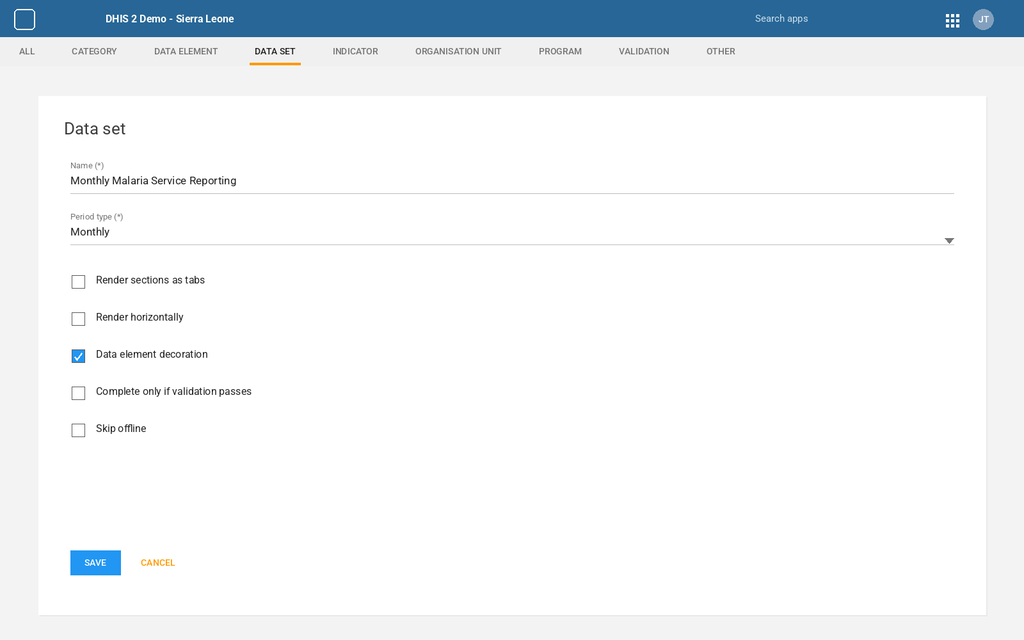

12345

**Figure 1.** The layout settings of the data set. *This picture was drawn for the guide to show what the screen looks like. Your screen will show your own names and dates.*

1. 1**Period type.** Monthly, so the form opens one month at a time.
2. 2**Render sections as tabs.** Off gives one long page. On gives a tab per section, which suits long forms.
3. 3**Render horizontally.** Off keeps one data element per row, which is easier to read.
4. 4**Data element decoration.** On shows the description of a data element as a small help icon in the form.
5. 5**SAVE.** Saves the settings.

Step 3: Build the Sections

Sections are the headings of the form. They were created in Topic 3, and this is where you shape them.

**Click:** Maintenance app → DATA SET tab → row menu → Manage sections → blue plus button

[figure not shown]

123456

**Figure 2.** The Add section window. *The data element names in this picture were changed to the ten you created, so the guide stays consistent.*

1. 1**Name.** The heading users read, such as Malaria Testing. Keep it short.
2. 2**Code.** Optional, useful when other systems refer to the section.
3. 3**Description.** Optional. It appears under the heading in some versions.
4. 4**Category combo filter.** Leave it as No filter unless the section should show only one breakdown.
5. 5**Search.** Shortens the list of data elements below.
6. 6**Data elements.** The fields of this section, in the order you move them across.

Step 4: Turn On Totals Where They Help

The same window carries three display options. They cost nothing and save the user arithmetic.

| Option | What it does | Use it when |
| --- | --- | --- |
| Show row totals | Adds a Total column at the end of each row | A field is split by sex or age and the total matters |
| Show column totals | Adds a Total row under the section | The section counts the same thing in several rows |
| Disable automatic grouping | Stops DHIS2 grouping fields by category combination | Rarely. Leave it off for this form |

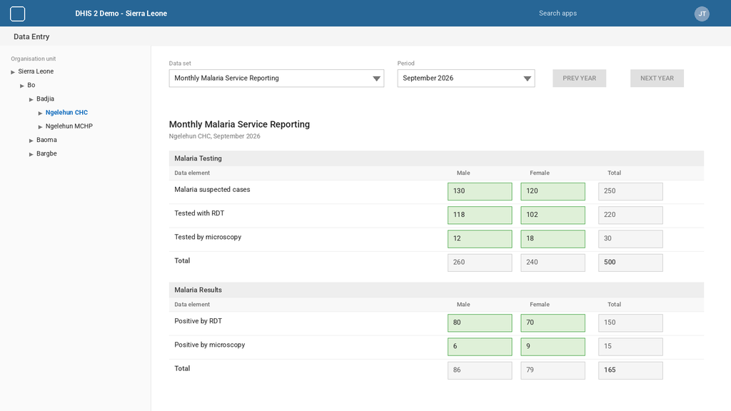

123

**Figure 3.** The same section with row and column totals switched on. *This picture was drawn for the guide to show what the screen looks like. Your screen will show your own names and dates.*

1. 1**Total column.** From Show row totals. Male plus Female for that field.
2. 2**Total row.** From Show column totals. The sum of the rows in that section.
3. 3**Typed values.** Only the white and green boxes are typed. The grey totals are worked out.

Step 5: Put the Sections in the Right Order

The order of the sections is the order of the form. Follow the register, not the alphabet.

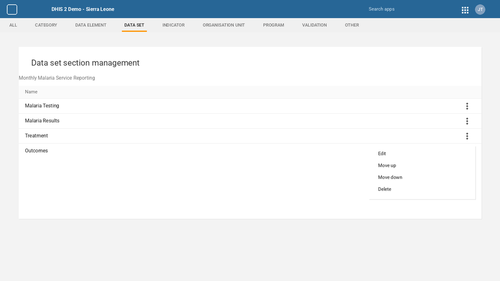

1234

**Figure 4.** Reordering the sections. *This picture was drawn for the guide to show what the screen looks like. Your screen will show your own names and dates.*

1. 1**The sections.** Shown in the order they appear in the form.
2. 2**Row menu.** The three dots of a section.
3. 3**Move up.** Moves the section one place earlier.
4. 4**Move down.** Moves it one place later. Repeat until the order matches the register.

Step 6: Order the Fields Inside a Section

Inside a section, the fields follow the order of the right hand list. Move one at a time, and use the arrows to fix the order.

[figure not shown]

12345

**Figure 5.** The order of the fields in the section. *The data element names in this picture were changed to the ten you created, so the guide stays consistent.*

1. 1**Available fields.** Everything in the data set that is not in this section.
2. 2**Arrow buttons.** Move one field at a time, so the order stays under your control.
3. 3**Selected fields.** The section, in form order.
4. 4**Up and down.** Move the highlighted field to fix the order.
5. 5**SAVE.** Saves the section.

Step 7: Give a Field a Short Label

Long data element names make a form hard to read. The **Form name** of a data element is what the form shows, and it can be much shorter than the full name.

**Click:** Maintenance app → DATA ELEMENT tab → open the data element → Form name

[figure not shown]

12

**Figure 6.** Name and form name of a data element.

1. 1**Name.** The full, unique name used everywhere in DHIS2.
2. 2**Form name.** What the data entry form shows. For example Suspected cases instead of Malaria Suspected Cases JT.

**Rule of thumb:** keep the full name precise, and the form name short.

Step 8: Decide Between One Page and Tabs

A long form is easier to work through as tabs. The setting is on the data set, from Step 2.

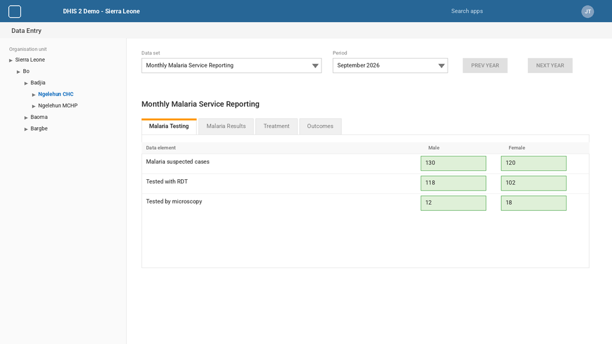

123

**Figure 7.** The same form with sections as tabs. *This picture was drawn for the guide to show what the screen looks like. Your screen will show your own names and dates.*

1. 1**The open tab.** One section at a time, with an orange underline.
2. 2**The other sections.** One click away, so the page stays short.
3. 3**The fields.** Exactly the same fields as the long page.

**Rule of thumb:** one page up to about four short sections, tabs beyond that.

Step 9: Open the Form in Data Entry

Open the Data Entry app, choose the facility, the data set and the month, and read the form as a user would.

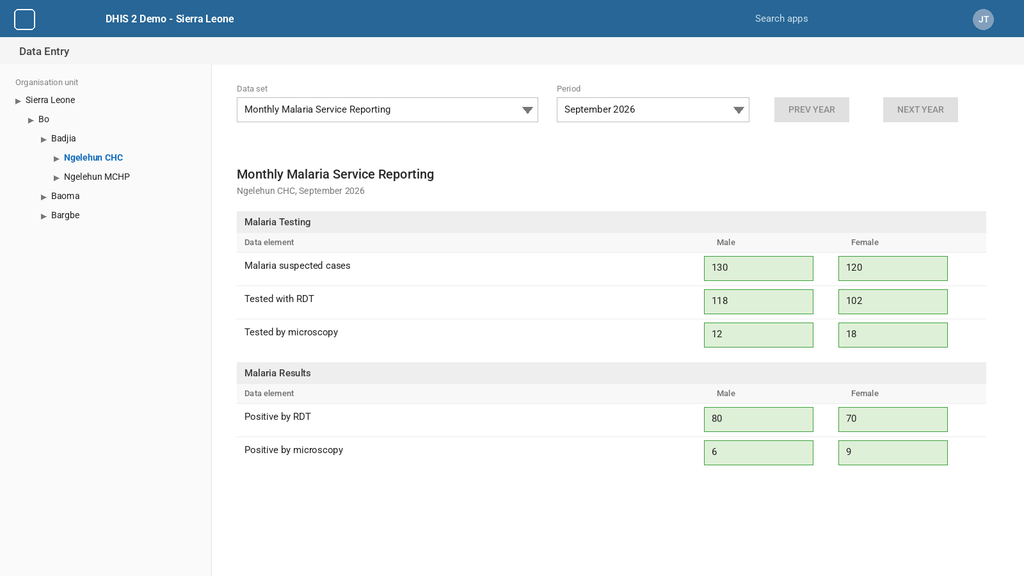

123

**Figure 8.** The finished section form. *This picture was drawn for the guide to show what the screen looks like. Your screen will show your own names and dates.*

1. 1**Section heading.** Grey bar with the section name.
2. 2**Male and Female.** The columns come from the category combination, not from the form design.
3. 3**A saved value.** A box turns green as soon as DHIS2 stores the number.

**Expected result:** A clear grouped form, with no code written anywhere.

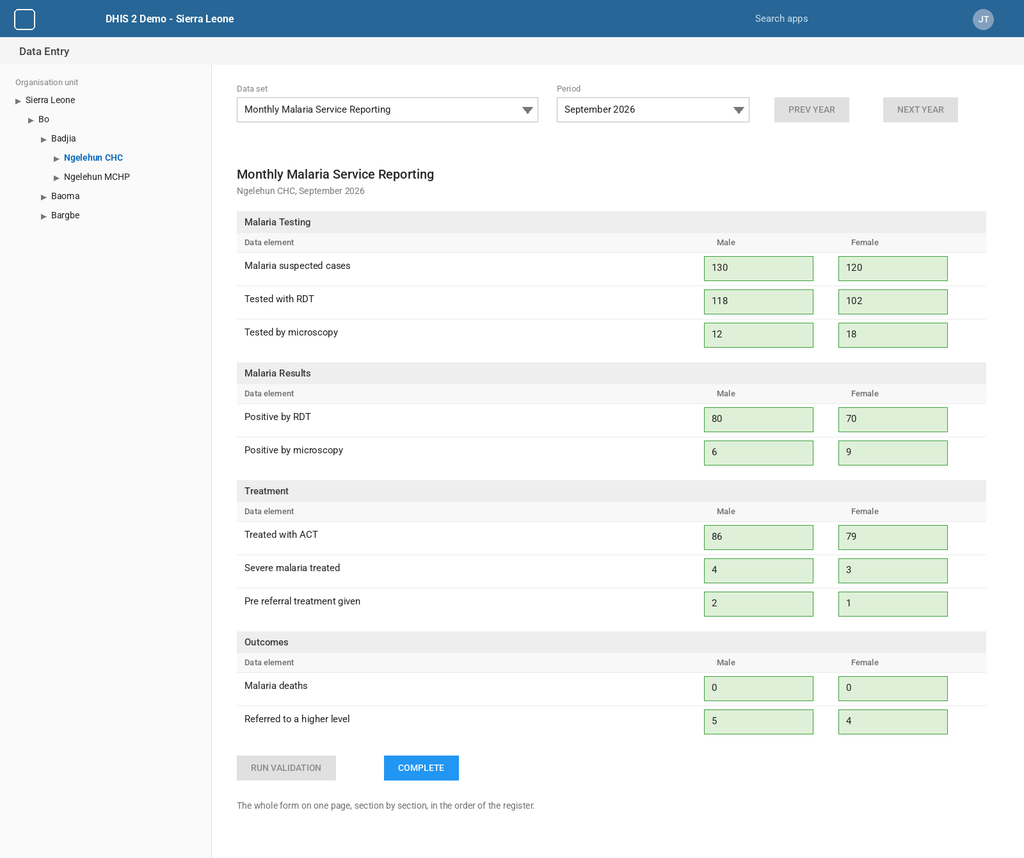

1234

**Figure 9.** The whole form on one page. *This picture was drawn for the guide to show what the screen looks like. Your screen will show your own names and dates.*

1. 1**First section.** The order of the sections is the order you set in Step 5.
2. 2**Later sections.** Each one keeps its own heading and its own columns.
3. 3**RUN VALIDATION.** Checks the values against the rules from Topic 3.
4. 4**COMPLETE.** Marks the report finished for this facility and month.

Step 10: Check the Form, Then Decide

Go through the list below with someone who will use the form.

- Sections follow the order of the register.
- Field labels are short and unambiguous.
- Totals appear only where they help.
- The form fits a small laptop screen without sideways scrolling.
- Compulsory fields are the ones the programme really insists on.

**Then hand it over:** when the list above is clear, the form is ready for the people who will use it every month.

DHIS2 Data Entry Form — Visual Design Guide